# Assignment6

PGIS/M/DTS/20/09

9/3/2021

# Q1

```r
library(ca)
```

```r
data(smoke)
```

```r
head(smoke)
```

```
##    none light medium heavy
## SM    4     2      3     2
## JM    4     3      7     4
## SE   25    10     12     4
## JE   18    24     33    13
## SC   10     6      7     2
```

This dataset contains frequencies of smoking habits (none, light, medium and heavy) for staff groups (senior managers, junior managers, senior employees, junior employees and secretaries) in a fictional company.

```r
summary(smoke)
```

```
##       none          light        medium         heavy
##  Min.   : 4.0   Min.   : 2   Min.   : 3.0   Min.   : 2
##  1st Qu.: 4.0   1st Qu.: 3   1st Qu.: 7.0   1st Qu.: 2
##  Median :10.0   Median : 6   Median : 7.0   Median : 4
##  Mean   :12.2   Mean   : 9   Mean   :12.4   Mean   : 5
##  3rd Qu.:18.0   3rd Qu.:10   3rd Qu.:12.0   3rd Qu.: 4
##  Max.   :25.0   Max.   :24   Max.   :33.0   Max.   :13
```

```r
smoke_ca = ca(smoke)
```

```r
smoke_ca
```

```
##
##  Principal inertias (eigenvalues):
##            1        2        3
## Value      0.074759 0.010017 0.000414
## Percentage 87.76%   11.76%   0.49%
##
##
##  Rows:
##                SM        JM        SE       JE        SC
## Mass     0.056995  0.093264  0.264249 0.455959  0.129534
## ChiDist  0.216559  0.356921  0.380779 0.240025  0.216169
## Inertia  0.002673  0.011881  0.038314 0.026269  0.006053
## Dim. 1  -0.240539  0.947105 -1.391973 0.851989 -0.735456
## Dim. 2  -1.935708 -2.430958 -0.106508 0.576944  0.788435
##
##
##  Columns:
##              none    light   medium     heavy
## Mass     0.316062 0.233161 0.321244  0.129534
## ChiDist  0.394490 0.173996 0.198127  0.355109
## Inertia  0.049186 0.007059 0.012610  0.016335
## Dim. 1  -1.438471 0.363746 0.718017  1.074445
## Dim. 2  -0.304659 1.409433 0.073528 -1.975960
```

most of the variance explained by the two Dimensions

```r
# sqrt of eigenvalues
smoke_ca$sv
```

```
## [1] 0.27342111 0.10008587 0.02033652
```

```r
head(smoke_ca$rowcoord)
```

```
##          Dim1       Dim2       Dim3
## SM -0.2405388 -1.9357079  3.4903231
## JM  0.9471047 -2.4309584 -1.6573725
## SE -1.3919733 -0.1065076 -0.2535221
## JE  0.8519895  0.5769437  0.1625337
## SC -0.7354557  0.7884353 -0.3973677
```

```r
head(smoke_ca$colcoord)
```

```
##              Dim1        Dim2        Dim3
## none   -1.4384714 -0.30465911 -0.04378737
## light   0.3637463  1.40943267  1.08170100
## medium  0.7180168  0.07352795 -1.26172451
## heavy   1.0744451 -1.97595989  1.28885615
```

```r
summary(smoke_ca)
```

```
##
## Principal inertias (eigenvalues):
##
##  dim    value      %   cum%   scree plot
##  1      0.074759  87.8  87.8  **********************
##  2      0.010017  11.8  99.5  ***
##  3      0.000414   0.5 100.0
##         -------- -----
##  Total: 0.085190 100.0
##
##
## Rows:
##     name   mass  qlt  inr    k=1 cor ctr    k=2 cor ctr
## 1 |   SM |   57  893   31 |  -66  92   3 | -194 800 214 |
## 2 |   JM |   93  991  139 |  259 526  84 | -243 465 551 |
## 3 |   SE |  264 1000  450 | -381 999 512 |  -11   1   3 |
## 4 |   JE |  456 1000  308 |  233 942 331 |   58  58 152 |
## 5 |   SC |  130  999   71 | -201 865  70 |   79 133  81 |
##
## Columns:
##     name   mass  qlt  inr    k=1 cor ctr    k=2 cor ctr
## 1 | none |  316 1000  577 | -393 994 654 |  -30   6  29 |
## 2 | lght |  233  984   83 |   99 327  31 |  141 657 463 |
## 3 | medm |  321  983  148 |  196 982 166 |    7   1   2 |
## 4 | hevy |  130  995  192 |  294 684 150 | -198 310 506 |
```

eigenvalues and relative percentages of explained inertia are given for all available dimensions. Dimension 1 explains 87.8% Pearson χ2 while dimension 2 explains 11.8% of Pearson χ2. Dimension 3 accounts for the rest (0.5%)

We can see that in component 2, the percentage of variability that can be explained drops steeply. It indicates that the addition of component 3 does not influence the data diversity that can be explained. So that component 1 and component 2 are chosen. The total percentage of variability that can be explained through the two selected components is about 99.5%

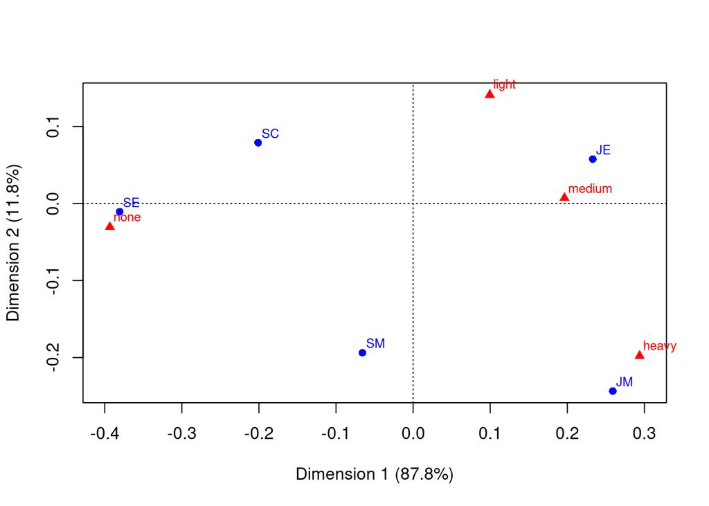

```r
plot(smoke_ca)
```

senior employees has a association with none smoking habit, junior managers seems to smoke heavily and junior employees has association with medium smoking habits.

# Q2

In this question we can consider only 4 variables and then all variables for the analysis

## Lets conside first 4 variables

(records of four questions on attitude towards science with responses on a five-point scale (1=agree strongly to 5=disagree strongly) )

```r
wg93[,1:4]
```

[output not shown]

[output cut: 857 more lines]

```r
mjca(wg93[,1:4])
```

```
##
##  Eigenvalues:
##            1        2       3        4       5        6
## Value      0.076455 0.05822 0.009197 0.00567 0.001172 7e-06
## Percentage 44.91%   34.2%   5.4%     3.33%   0.69%    0%
##
##
##  Columns:
##               A:1      A:2       A:3       A:4       A:5       B:1      B:2
## Mass     0.034156 0.092423  0.058553  0.051091  0.013777  0.020379 0.049943
## ChiDist  1.343394 0.676433  0.947274  1.049164  2.214898  1.856041 1.034203
## Inertia  0.061642 0.042289  0.052542  0.056238  0.067588  0.070203 0.053417
## Dim. 1   1.836627 0.546240 -0.446797 -1.165903 -1.995217  2.924321 0.641516
## Dim. 2  -0.727459 0.284443  1.199439 -0.736782 -2.470026 -1.370078 0.666938
##              B:3       B:4       B:5       C:1      C:2       C:3       C:4
## Mass    0.058840  0.080654  0.040184  0.043628 0.090700  0.056544  0.044202
## ChiDist 0.933288  0.760011  1.294006  1.241063 0.688137  0.977789  1.148345
## Inertia 0.051252  0.046587  0.067286  0.067197 0.042950  0.054060  0.058289
## Dim. 1  0.346050 -0.714126 -1.353725  2.157782 0.246828 -0.618996 -1.348858
## Dim. 2  0.963918  0.280071 -2.107677 -0.908553 0.591611  1.044412 -0.634647
##               C:5       D:1       D:2       D:3       D:4       D:5
## Mass     0.014925  0.017222  0.066590  0.057979  0.064868  0.043341
## ChiDist  2.132827  1.915937  0.843092  0.962007  0.860714  1.136559
## Inertia  0.067895  0.063217  0.047333  0.053657  0.048056  0.055986
## Dim. 1  -1.467582  1.203782 -0.221151 -0.384656 -0.221635  0.707750
## Dim. 2  -3.016588 -1.821975  0.006935  1.158694  0.210513 -1.151804
```

Dimension 1 explains 44.91% Pearson χ2 while dimension 2 explains 34.2% of Pearson χ2. We can see that total dimensions don’t explain 100%.

```r
summary(mjca(wg93[,1:4], lambda = "Burt"))
```

```
##
## Principal inertias (eigenvalues):
##
##  dim    value      %   cum%   scree plot
##  1      0.209196  18.6  18.6  *****
##  2      0.185732  16.5  35.0  ****
##  3      0.103636   9.2  44.2  **
##  4      0.093926   8.3  52.5  **
##  5      0.075997   6.7  59.3  **
##  6      0.063468   5.6  64.9  *
##  7      0.058835   5.2  70.1  *
##  8      0.055202   4.9  75.0  *
##  9      0.050836   4.5  79.5  *
##  10     0.048677   4.3  83.8  *
##  11     0.044032   3.9  87.7  *
```

[output cut: 31 more lines]

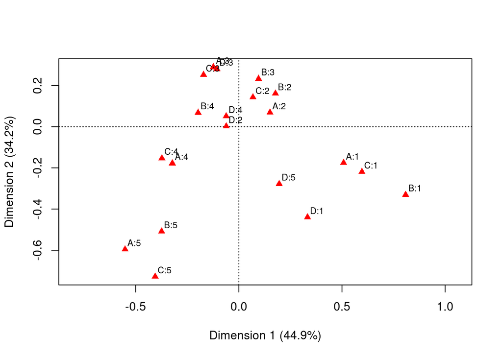

```r
plot.mjca(mjca(wg93[,1:4]))
```

## Analysis using all the variables

```r
# load packages
require(FactoMineR)
```

```r
require(ggplot2)
data(wg93)
```

```r
# number of categories per variable
wgapply = apply(wg93, 2, function(x) nlevels(as.factor(x)))
wgapply
```

```
##   A   B   C   D sex age edu
##   5   5   5   5   2   6   6
```

```r
# apply MCA
mca1 = MCA(wg93, graph = FALSE)
```

```r
# table of eigenvalues
mca1$eig
```

```
##        eigenvalue percentage of variance cumulative percentage of variance
## dim 1  0.28863097               7.483025                          7.483025
## dim 2  0.25473881               6.604339                         14.087365
## dim 3  0.20829251               5.400176                         19.487541
## dim 4  0.19738826               5.117473                         24.605014
## dim 5  0.18252871               4.732226                         29.337240
## dim 6  0.16777120               4.349624                         33.686864
## dim 7  0.16513859               4.281371                         37.968235
## dim 8  0.15963130               4.138589                         42.106824
## dim 9  0.15728148               4.077668                         46.184492
## dim 10 0.15090458               3.912341                         50.096833
## dim 11 0.14749027               3.823822                         53.920654
## dim 12 0.14387158               3.730004                         57.650658
## dim 13 0.13883734               3.599487                         61.250145
## dim 14 0.13338181               3.458047                         64.708192
## dim 15 0.12948212               3.356944                         68.065135
## dim 16 0.12716579               3.296891                         71.362026
## dim 17 0.12653319               3.280490                         74.642516
## dim 18 0.12201043               3.163233                         77.805750
## dim 19 0.11660840               3.023181                         80.828931
## dim 20 0.11158366               2.892910                         83.721840
## dim 21 0.10660185               2.763752                         86.485592
## dim 22 0.09758714               2.530037                         89.015629
## dim 23 0.09419675               2.442138                         91.457767
## dim 24 0.09248798               2.397837                         93.855604
## dim 25 0.08524996               2.210184                         96.065788
## dim 26 0.08246419               2.137960                         98.203748
## dim 27 0.06928400               1.796252                        100.000000
```

```r
# column coordinates
head(mca1$var$coord)
```

```
##          Dim 1       Dim 2       Dim 3       Dim 4       Dim 5
## A_1 -0.9671597  0.82273703  0.20937924 -0.42460797  0.07117658
## A_2 -0.4260310 -0.07132741 -0.08186277  0.15141118 -0.05311328
## A_3  0.1803910 -0.84426258 -0.06866201 -0.43681468  0.30997012
## A_4  0.7686636  0.22766291  0.29174984  0.48798870 -0.66303991
## A_5  1.6385852  1.18265182 -0.76001539  0.08379486  1.32124301
## B_1 -1.4660261  1.39035983  0.25123381 -0.73875510 -0.14521786
```

```r
# row coordinates
head(mca1$ind$coord)
```

```
##         Dim 1       Dim 2       Dim 3        Dim 4       Dim 5
## 1  0.11499250 -0.27770305  0.37659700 -0.381401003  0.08018182
## 2  0.41006038 -0.49873124  0.36342941 -0.430248783  0.10672424
## 3 -0.40942003 -0.29751789 -0.11214232 -0.002271375 -0.23362381
## 4 -0.13828751 -0.31763706 -0.23336334  0.102448643 -0.22324271
## 5 -0.05922076 -0.94515366 -0.24346523 -0.242920044  0.57325148
## 6  0.36408422 -0.09272563 -0.03236819 -0.320929753 -0.57369780
```

```r
summary(MCA(wg93, graph = FALSE))
```

```
##
## Call:
## MCA(X = wg93, graph = FALSE)
##
##
## Eigenvalues
##                        Dim.1   Dim.2   Dim.3   Dim.4   Dim.5   Dim.6   Dim.7
## Variance               0.289   0.255   0.208   0.197   0.183   0.168   0.165
## % of var.              7.483   6.604   5.400   5.117   4.732   4.350   4.281
## Cumulative % of var.   7.483  14.087  19.488  24.605  29.337  33.687  37.968
##                        Dim.8   Dim.9  Dim.10  Dim.11  Dim.12  Dim.13  Dim.14
## Variance               0.160   0.157   0.151   0.147   0.144   0.139   0.133
## % of var.              4.139   4.078   3.912   3.824   3.730   3.599   3.458
## Cumulative % of var.  42.107  46.184  50.097  53.921  57.651  61.250  64.708
##                       Dim.15  Dim.16  Dim.17  Dim.18  Dim.19  Dim.20  Dim.21
## Variance               0.129   0.127   0.127   0.122   0.117   0.112   0.107
## % of var.              3.357   3.297   3.280   3.163   3.023   2.893   2.764
## Cumulative % of var.  68.065  71.362  74.643  77.806  80.829  83.722  86.486
##                       Dim.22  Dim.23  Dim.24  Dim.25  Dim.26  Dim.27
## Variance               0.098   0.094   0.092   0.085   0.082   0.069
## % of var.              2.530   2.442   2.398   2.210   2.138   1.796
## Cumulative % of var.  89.016  91.458  93.856  96.066  98.204 100.000
##
## Individuals (the 10 first)
##        Dim.1    ctr   cos2    Dim.2    ctr   cos2    Dim.3    ctr   cos2
## 1   |  0.115  0.005  0.005 | -0.278  0.035  0.028 |  0.377  0.078  0.051 |
## 2   |  0.410  0.067  0.049 | -0.499  0.112  0.072 |  0.363  0.073  0.038 |
## 3   | -0.409  0.067  0.072 | -0.298  0.040  0.038 | -0.112  0.007  0.005 |
## 4   | -0.138  0.008  0.008 | -0.318  0.045  0.042 | -0.233  0.030  0.022 |
## 5   | -0.059  0.001  0.001 | -0.945  0.403  0.289 | -0.243  0.033  0.019 |
## 6   |  0.364  0.053  0.043 | -0.093  0.004  0.003 | -0.032  0.001  0.000 |
## 7   | -0.133  0.007  0.007 | -0.501  0.113  0.096 | -0.039  0.001  0.001 |
## 8   |  0.578  0.133  0.112 | -0.428  0.082  0.061 | -0.105  0.006  0.004 |
## 9   | -0.358  0.051  0.030 | -0.158  0.011  0.006 | -0.537  0.159  0.069 |
## 10  | -0.117  0.005  0.005 | -0.630  0.179  0.155 | -0.572  0.181  0.128 |
##
## Categories (the 10 first)
##         Dim.1     ctr    cos2  v.test     Dim.2     ctr    cos2  v.test
## A_1 |  -0.967   6.325   0.148 -11.348 |   0.823   5.186   0.107   9.654 |
## A_2 |  -0.426   3.321   0.106  -9.624 |  -0.071   0.105   0.003  -1.611 |
```

[output cut: 14 more lines]

```
## B_1   0.251   0.353   0.006   2.208 |
## B_2  -0.067   0.062   0.001  -0.991 |
## B_3  -0.064   0.067   0.001  -1.055 |
## B_4   0.366   2.970   0.064   7.457 |
## B_5  -0.685   5.169   0.090  -8.839 |
##
## Categorical variables (eta2)
##       Dim.1 Dim.2 Dim.3
## A   | 0.471 0.349 0.059 |
## B   | 0.544 0.418 0.126 |
## C   | 0.519 0.486 0.203 |
## D   | 0.026 0.395 0.160 |
## sex | 0.069 0.026 0.055 |
## age | 0.158 0.030 0.391 |
## edu | 0.233 0.080 0.464 |
```

Here Dimensions Cumulative variance account for 100%

```r
# data frames for ggplot
mca1_vars_df = data.frame(mca1$var$coord, Variable = rep(names(wgapply),wgapply))
mca1_obs_df = data.frame(mca1$ind$coord)
```

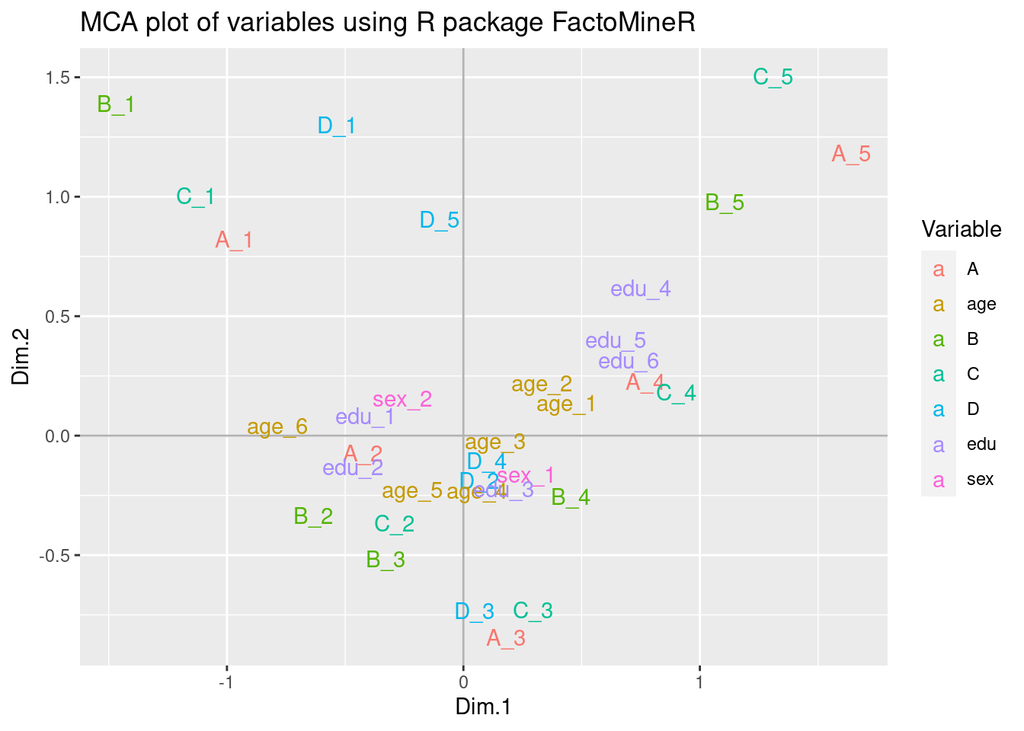

```r
# plot of variable categories
ggplot(data = mca1_vars_df, aes(x = Dim.1, y = Dim.2, label = rownames(mca1_vars_df))) +
    geom_hline(yintercept = 0, colour = "gray70") + geom_vline(xintercept = 0,
    colour = "gray70") + geom_text(aes(colour = Variable)) + ggtitle("MCA plot of variables using R package FactoMineR")
```

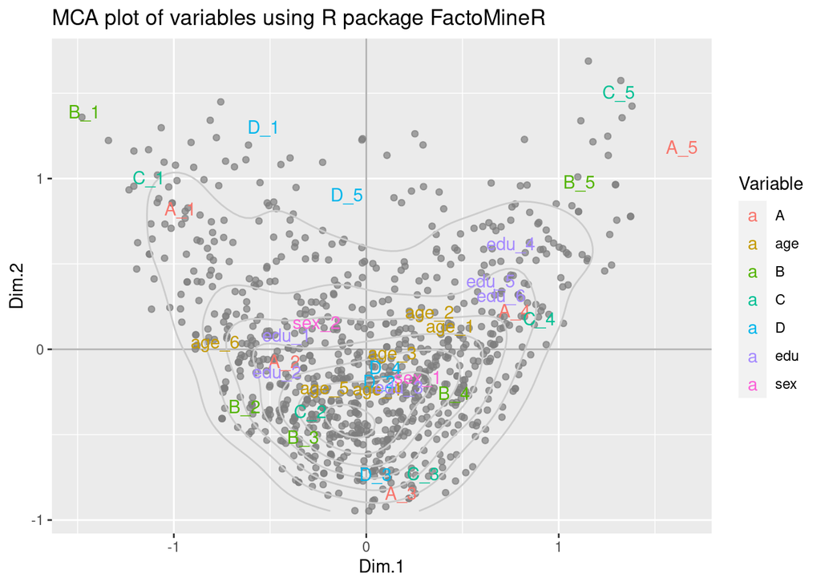

```r
# MCA plot of observations and categories
ggplot(data = mca1_obs_df, aes(x = Dim.1, y = Dim.2)) + geom_hline(yintercept = 0,
    colour = "gray70") + geom_vline(xintercept = 0, colour = "gray70") + geom_point(colour = "gray50",
    alpha = 0.7) + geom_density2d(colour = "gray80") + geom_text(data = mca1_vars_df,
    aes(x = Dim.1, y = Dim.2, label = rownames(mca1_vars_df), colour = Variable)) +
    ggtitle("MCA plot of variables using R package FactoMineR") + scale_colour_discrete(name = "Variable")
```

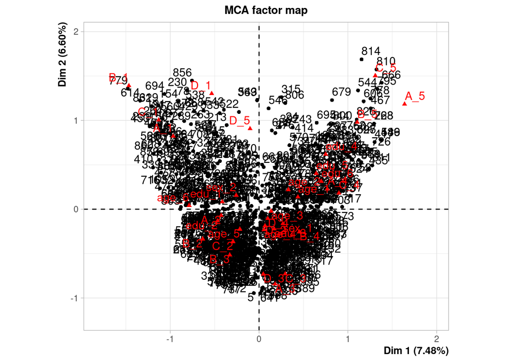

```r
# default biplot in FactoMineR
plot(mca1)
```